# Jackson Heart Study (JHS) analysis of the best model

Author

Oscar Hernandez Mata

```r
library(tidyverse)
library(dplyr)
library(haven)
library(haven)
analysis1 <- read_sas("analysis1.sas7bdat",
    NULL)
library(ggplot2)
library(fastDummies)
library(data.table)
library(equatiomatic)
library(lindia)
library(car)
library(sjPlot)
library(nnet)
library(lmtest)
library(AER)
library(mlogit)
library(MASS)
library(brant)
library(boot)
library(tictoc)
library(caret)
library(ordinal)
```

#### 1. I used leave-one-out cross validation to determine which model fit better:

#### 2. Systolic blood pressure (*sbp*; mmHg) as a function of age (*age*; years), education (*HSgrad*; 0=no, 1=yes), diabetic status (*diab3cat*; 0=non-diabetic, 1=pre-diabetic, 2=diabetic), body mass index (*bmi*, kg/m2), the interaction between diabetic status and age, and the interaction between diabetic status and education.

```r
data1=analysis1%>%dplyr::select(
sbp,
age,
HSgrad,
diab3cat,
BMI,
Diabetes,
weight,
HTN,
hdl3cat
)%>%
  na.omit()

data1$diab3cat=as.factor(data1$diab3cat)

m1=glm(sbp~age+HSgrad+diab3cat+BMI+diab3cat:age+diab3cat:HSgrad, data=data1)
summary(m1)
```

```
Call:
glm(formula = sbp ~ age + HSgrad + diab3cat + BMI + diab3cat:age +
    diab3cat:HSgrad, data = data1)

Deviance Residuals:
    Min       1Q   Median       3Q      Max
-44.136   -9.831   -1.068    7.887   59.591

Coefficients:
                  Estimate Std. Error t value Pr(>|t|)
(Intercept)      93.923410   3.012963  31.173  < 2e-16 ***
age               0.471729   0.036758  12.833  < 2e-16 ***
HSgrad           -1.092589   1.544484  -0.707  0.47938
diab3cat1         1.132422   4.162639   0.272  0.78561
diab3cat2        18.114301   5.867404   3.087  0.00204 **
BMI               0.220207   0.044343   4.966 7.31e-07 ***
age:diab3cat1     0.003341   0.059723   0.056  0.95539
age:diab3cat2    -0.276837   0.085323  -3.245  0.00119 **
HSgrad:diab3cat1 -0.386585   2.070410  -0.187  0.85190
HSgrad:diab3cat2 -0.464252   2.459114  -0.189  0.85027
---
Signif. codes:  0 '***' 0.001 '**' 0.01 '*' 0.05 '.' 0.1 ' ' 1

(Dispersion parameter for gaussian family taken to be 210.3349)

    Null deviance: 594996  on 2448  degrees of freedom
Residual deviance: 513007  on 2439  degrees of freedom
AIC: 20061

Number of Fisher Scoring iterations: 2
```

#### 3. Systolic blood pressure (*sbp*; mmHg) as a function of age (*age*; years), education (*HSgrad*; 0=no, 1=yes), diabetic status (*diab3cat*; 0=non-diabetic, 1=pre-diabetic, 2=diabetic), body mass index (*bmi*, kg/m2).

```r
m2=glm(sbp~age+HSgrad+diab3cat+BMI, data=data1)
summary(m2)
```

```
Call:
glm(formula = sbp ~ age + HSgrad + diab3cat + BMI, data = data1)

Deviance Residuals:
    Min       1Q   Median       3Q      Max
-43.383   -9.853   -1.189    8.015   61.710

Coefficients:
            Estimate Std. Error t value Pr(>|t|)
(Intercept) 95.34972    2.41462  39.488  < 2e-16 ***
age          0.44004    0.02748  16.015  < 2e-16 ***
HSgrad      -1.23228    0.90561  -1.361   0.1737
diab3cat1    1.15354    0.68556   1.683   0.0926 .
diab3cat2    1.64524    0.89776   1.833   0.0670 .
BMI          0.23024    0.04420   5.210 2.05e-07 ***
---
Signif. codes:  0 '***' 0.001 '**' 0.01 '*' 0.05 '.' 0.1 ' ' 1

(Dispersion parameter for gaussian family taken to be 211.0364)

    Null deviance: 594996  on 2448  degrees of freedom
Residual deviance: 515562  on 2443  degrees of freedom
AIC: 20065

Number of Fisher Scoring iterations: 2
```

```r
set.seed(45)
cv_error <- cv.glm(data1, m1)
cv_error$delta
```

```
[1] 211.3789 211.3785
```

```r
set.seed(45)
cv_error <- cv.glm(data1, m2)
cv_error$delta
```

```
[1] 211.6515 211.6512
```

We calculated the CV(n) of models 1 and 2 (m1=211.3789 211.3785; m2=211.6515 211.6512). In this case m1 CV(n) < m2 CV(n). Thus, we can conclude that m1 fits better than m2.

#### 4. Diabetic status (*Diabetes*; 0=non-diabetic, 1=diabetic) as a function of age (*age*; years), weight (*weight*; kg), hypertension status (*HTN*; 0=normotensive, 1=hypertensive), health status as indicated by high density lipoproteins (*hdl3cat*; 0=poor health, 1=intermediate health, 2=ideal health), the interaction between weight and hypertension status, the interaction between weight and age, and the interaction between weight and health status as indicated by high density lipoproteins.

```r
data1$hdl3cat=as.factor(data1$hdl3cat)
m3=glm(Diabetes~age+weight+HTN+hdl3cat+weight:HTN+weight:age+weight:hdl3cat, data=data1, family = "binomial")
summary(m3)
```

```
Call:
glm(formula = Diabetes ~ age + weight + HTN + hdl3cat + weight:HTN +
    weight:age + weight:hdl3cat, family = "binomial", data = data1)

Deviance Residuals:
    Min       1Q   Median       3Q      Max
-1.6378  -0.6745  -0.4291  -0.2487   2.6651

Coefficients:
                  Estimate Std. Error z value Pr(>|z|)
(Intercept)     -6.3675158  1.2576815  -5.063 4.13e-07 ***
age              0.0196975  0.0235845   0.835 0.403613
weight           0.0215474  0.0121108   1.779 0.075208 .
HTN              2.3347455  0.6146041   3.799 0.000145 ***
hdl3cat1        -0.5578487  0.6093974  -0.915 0.359976
hdl3cat2         0.5281387  0.6853983   0.771 0.440969
weight:HTN      -0.0139384  0.0060829  -2.291 0.021939 *
age:weight       0.0002349  0.0002361   0.995 0.319757
weight:hdl3cat1  0.0015756  0.0060062   0.262 0.793074
weight:hdl3cat2 -0.0114672  0.0072387  -1.584 0.113159
---
Signif. codes:  0 '***' 0.001 '**' 0.01 '*' 0.05 '.' 0.1 ' ' 1

(Dispersion parameter for binomial family taken to be 1)

    Null deviance: 2215.9  on 2448  degrees of freedom
Residual deviance: 1953.6  on 2439  degrees of freedom
AIC: 1973.6

Number of Fisher Scoring iterations: 5
```

```r
m4=glm(Diabetes~age+weight+HTN+hdl3cat, data=data1, family = "binomial")
summary(m4)
```

```
Call:
glm(formula = Diabetes ~ age + weight + HTN + hdl3cat, family = "binomial",
    data = data1)

Deviance Residuals:
    Min       1Q   Median       3Q      Max
-1.6291  -0.6631  -0.4272  -0.2698   2.6468

Coefficients:
             Estimate Std. Error z value Pr(>|z|)
(Intercept) -6.425836   0.482617 -13.315  < 2e-16 ***
age          0.042127   0.005874   7.172 7.37e-13 ***
weight       0.022285   0.002767   8.055 7.97e-16 ***
HTN          0.974809   0.137050   7.113 1.14e-12 ***
hdl3cat1    -0.400469   0.130398  -3.071 0.002132 **
hdl3cat2    -0.515259   0.152846  -3.371 0.000749 ***
---
Signif. codes:  0 '***' 0.001 '**' 0.01 '*' 0.05 '.' 0.1 ' ' 1

(Dispersion parameter for binomial family taken to be 1)

    Null deviance: 2215.9  on 2448  degrees of freedom
Residual deviance: 1962.1  on 2443  degrees of freedom
AIC: 1974.1

Number of Fisher Scoring iterations: 5
```

Note: I created the required model plus an alternative model without the interactions to check which model fit better.

#### 5. 2-fold cross validation.

```r
tic()
set.seed(80)
cv_errorm3k2 <- cv.glm(data1, m3, K=2)
cv_errorm3k2$delta
```

```
[1] 0.1284546 0.1277512
```

```r
set.seed(80)
cv_errorm4k2 <- cv.glm(data1, m4, K=2)
cv_errorm4k2$delta
```

```
[1] 0.1287157 0.1281067
```

```r
toc()
```

```
0.096 sec elapsed
```

```r
cv_errorm3k2$delta>cv_errorm4k2$delta
```

```
[1] FALSE FALSE
```

We calculated the CV(k=2) for m3 and m4 (m3=0.1284546 0.1277512, m4=0.1287157 0.1281067) at a set seed of 80. In this case m3 CV(k=2) < m4 CV(k=2). Thus, we conclude that m3 is better fit than m4.

#### 6. 5-fold cross validation.

```r
tic()
set.seed(80)
cv_errorm3k5<- cv.glm(data1, m3, K=5)
cv_errorm3k5$delta
```

```
[1] 0.1276897 0.1275400
```

```r
set.seed(80)
cv_errorm4k5 <- cv.glm(data1, m4, K=5)
cv_errorm4k5$delta
```

```
[1] 0.1277556 0.1276539
```

```r
toc()
```

```
0.423 sec elapsed
```

```r
cv_errorm3k5$delta>cv_errorm4k5$delta
```

```
[1] FALSE FALSE
```

I calculated the CV(k=5) for m3 and m4 (m3=0.1276897 0.1275400, m4=0.1277556 0.1276539) at a set seed of 80. In this case m3 CV(k=5) < m4 CV(k=5). Thus, I concluded that m3 is better fit than m4.

#### 7. 10-fold cross validation.

```r
tic()
set.seed(80)
cv_errorm3k10 <- cv.glm(data1, m3, K=10)
cv_errorm3k10$delta
```

```
[1] 0.1276424 0.1275762
```

```r
set.seed(80)
cv_errorm4k10 <- cv.glm(data1, m4, K=10)
cv_errorm4k10$delta
```

```
[1] 0.1277778 0.1277304
```

```r
toc()
```

```
0.614 sec elapsed
```

```r
cv_errorm3k10$delta>cv_errorm4k10$delta
```

```
[1] FALSE FALSE
```

I calculated the CV(k=10) for m3 and m4 (m3=0.1276424 0.1275762, m4=0.1277778 0.1277304) at a set seed of 80. In this case m3 CV(k=10) < m4 CV(k=10). Thus, I concluded that m3 is better fit than m4.

#### 8. 25-fold cross validation.

```r
tic()
set.seed(80)
cv_errorm3k25 <- cv.glm(data1, m3, K=25)
cv_errorm3k25$delta
```

```
[1] 0.1275292 0.1275048
```

```r
set.seed(80)
cv_errorm4k25 <- cv.glm(data1, m4, K=25)
cv_errorm4k25$delta
```

```
[1] 0.1275060 0.1274928
```

```r
toc()
```

```
0.988 sec elapsed
```

```r
cv_errorm3k25$delta>cv_errorm4k25$delta
```

```
[1] TRUE TRUE
```

I calculated the CV(k=25) for m3 and m4 (m3=0.1275292 0.1275048, m4=0.1275060 0.1274928) at a set seed of 80. In this case m3 CV(k=25) > m4 CV(k=25). Thus, I concluded that m4 is better fit than m3.

#### 9. 50-fold cross validation.

```r
tic()
set.seed(80)
cv_errorm3k50 <- cv.glm(data1, m3, K=50)
cv_errorm3k50$delta
```

```
[1] 0.1276650 0.1276517
```

```r
set.seed(80)
cv_errorm4k50 <- cv.glm(data1, m4, K=50)
cv_errorm4k50$delta
```

```
[1] 0.1276131 0.1276059
```

```r
toc()
```

```
2.238 sec elapsed
```

```r
cv_errorm3k50$delta>cv_errorm4k50$delta
```

```
[1] TRUE TRUE
```

#### 10. 100-fold cross validation.

```r
tic()
set.seed(80)
cv_errorm3k100 <- cv.glm(data1, m3, K=100)
cv_errorm3k100$delta
```

```
[1] 0.1276038 0.1275974
```

```r
set.seed(80)
cv_errorm4k100 <- cv.glm(data1, m4, K=100)
cv_errorm4k100$delta
```

```
[1] 0.1275948 0.1275912
```

```r
toc()
```

```
4.497 sec elapsed
```

```r
cv_errorm3k100$delta>cv_errorm4k100$delta
```

```
[1] TRUE TRUE
```

I calculated the CV(k=100) for m3 and m4 (m3=0.1276038 0.1275974, m4=0.1275948 0.1275912) at a set seed of 80. In this case m3 CV(k=100) > m4 CV(k=100). Thus, I conclude that m4 is better fit than m3.

Note: As the number of k groups or folds increased the CV(k) in general decreased.This is because the model is trained on a bigger training group and tested on a smaller test group. Therefore, the performance of the model will likely have a higher confidence in the cross validation and thus will be more accurate as the folds increase. In our example, the CV(k=2) > CV(k=100). On the other hand, the processing time increased as the k groups or folds increased. This is because the model will be trained in a larger amount of folds, resulting in more time to compute.

#### 11. I used 25-fold cross validation to determine which model fit better:

#### 12. Number of ideal health indicators (use blood pressure (*idealHealthBP*; 1=ideal health, 0=not ideal health), smoking status (*idealHealthSMK*; 1=ideal health, 0=not ideal health), diabetes (*idealHealthDM*; 1=ideal health, 0=not ideal health), diet (idealHealthNutrition; 1=ideal health, 0=not ideal health), physical activity (*idealHealthPA*; 1=ideal health, 0=not ideal health), obesity (*idealHealthBMI*; 1=ideal health, 0=not ideal health), and high cholesterol (*idealHealthChol*; 1=ideal health, 0=not ideal health)) as a function of age (*age*; years), health insurance (*PrivatePublicIns*; 0=uninsured, 1=private insurance only, 2=public insurance only, 3=private and public insurances), education status (*HSgrad*; 0=did not graduate high school, 1=graduated high school), and the interaction between age and health insurance.

```r
data2=analysis1%>%dplyr::select(
  age,
  PrivatePublicIns,
  HSgrad,
  idealHealthBP,
  idealHealthSMK,
  idealHealthDM,
  idealHealthNutrition,
  idealHealthPA,
  idealHealthBMI,
  idealHealthChol
  )%>%
  na.omit()


data2 = data2 %>%
  mutate(ideal_health_indicators = rowSums(dplyr::select(., idealHealthBP:idealHealthChol) == 1, na.rm = TRUE))

#count(data2, ideal_health_indicators)

mean(data2$ideal_health_indicators)
```

```
[1] 2.36039
```

```r
var(data2$ideal_health_indicators)
```

```
[1] 1.382356
```

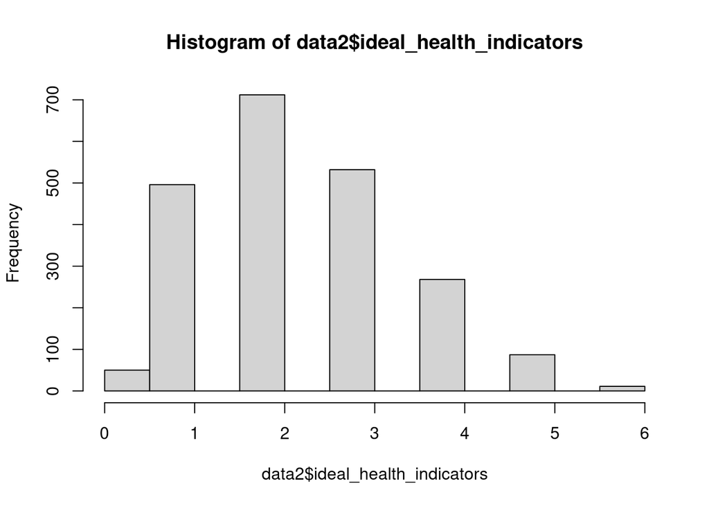

```r
hist(data2$ideal_health_indicators)
```

```r
data2$PrivatePublicIns=as.factor(data2$PrivatePublicIns)

m5 = glm.nb(ideal_health_indicators ~ age + PrivatePublicIns + HSgrad+age:PrivatePublicIns, data=data2)
summary(m5)
```

```
Call:
glm.nb(formula = ideal_health_indicators ~ age + PrivatePublicIns +
    HSgrad + age:PrivatePublicIns, data = data2, init.theta = 83541.30786,
    link = log)

Deviance Residuals:
     Min        1Q    Median        3Q       Max
-2.54346  -0.61648  -0.02272   0.44952   1.93048

Coefficients:
                        Estimate Std. Error z value Pr(>|z|)
(Intercept)            1.6228188  0.2075565   7.819 5.34e-15 ***
age                   -0.0174785  0.0040246  -4.343 1.41e-05 ***
PrivatePublicIns1      0.0960865  0.2150427   0.447  0.65500
PrivatePublicIns2     -1.0969694  0.3685732  -2.976  0.00292 **
PrivatePublicIns3     -0.3508021  0.3936761  -0.891  0.37288
HSgrad                 0.0714601  0.0505950   1.412  0.15783
age:PrivatePublicIns1  0.0004006  0.0043806   0.091  0.92714
age:PrivatePublicIns2  0.0175373  0.0061682   2.843  0.00447 **
age:PrivatePublicIns3  0.0080899  0.0064776   1.249  0.21170
---
Signif. codes:  0 '***' 0.001 '**' 0.01 '*' 0.05 '.' 0.1 ' ' 1

(Dispersion parameter for Negative Binomial(83541.31) family taken to be 1)

    Null deviance: 1348.6  on 2155  degrees of freedom
Residual deviance: 1153.8  on 2147  degrees of freedom
AIC: 6836.7

Number of Fisher Scoring iterations: 1

              Theta:  83541
          Std. Err.:  258268
Warning while fitting theta: iteration limit reached

 2 x log-likelihood:  -6816.74
```

Note: The count function is giving error. I removed the dplyr package and reinstalled it and it’s still not working unless I use data2$ideal_health_indicators. However, if I use this code it will not render in the end.

#### 13. Number of ideal health indicators (use blood pressure (*idealHealthBP*; 1=ideal health, 0=not ideal health), smoking status (*idealHealthSMK*; 1=ideal health, 0=not ideal health), diabetes (*idealHealthDM*; 1=ideal health, 0=not ideal health), diet (idealHealthNutrition; 1=ideal health, 0=not ideal health), physical activity (*idealHealthPA*; 1=ideal health, 0=not ideal health), obesity (*idealHealthBMI*; 1=ideal health, 0=not ideal health), and high cholesterol (*idealHealthChol*; 1=ideal health, 0=not ideal health)) as a function of age (*age*; years), health insurance (*PrivatePublicIns*; 0=uninsured, 1=private insurance only, 2=public insurance only, 3=private and public insurances), education status (*HSgrad*; 0=did not graduate high school, 1=graduated high school).

```r
m6 = glm.nb(ideal_health_indicators ~ age + PrivatePublicIns + HSgrad, data=data2)

set.seed(100)
cv_error <- cv.glm(data2, m5, K=25)
cv_error$delta
```

```
[1] 1.168876 1.168686
```

```r
cv_error <- cv.glm(data2, m6, K=25)
cv_error$delta
```

```
[1] 1.177968 1.177830
```

I calculated the CV(k=25) for m5 and m6 (m5=1.168876 1.168686, m6=1.177968 1.177830) at a set seed of 100. In this case m5 CV(k=25) < m6 CV(k=25). Thus, I concluded that m5 is better fit than m6.

#### 14. Summary

In the first case I built two models in order to predict the impact of age, education, diabetic categories, body mass index, the interaction between age and the diabetic categories (how age and diabetic categories together impact systolic blood), and the interaction between diabetic categories and education (how education and diabetic categories together impact systolic blood pressure) on systolic blood pressure. Subsequently, I built a second model with the same characteristics, however I did not include the interactions. Next, I ran a test known as leave one out cross validation, to check what model worked better to predict the impact on systolic blood pressure. My results concluded that model one with the interactions was a better fit for the analysis.